# Анализ набора данных

Громов В.П.

# Постановка задачи

Исследуйте зависимость величины `ow = Ozone/Wind` от `Temp` в таблице `airquality`, сравните распределение ow по месяцам

## Решение (код)

Для работы понядобятся библиотеки **ggplot2** и **dplyr**. Что есть в программе:

1. Функция, добавляющая необходимую величину `ow` в датафрейм (`addOW()`)
2. Функция построения графика зависимости максимального значения `ow` от `Month` (`OWMonth_s(aqow)`)
3. Функция построения графика распределения `ow` по определенному месяцу (`OWMonth(aqow,i)`)
4. Функция построения графика зависимости `ow` от `Temp` (`OWTemp(aqow)`)
5. Функция, строящая гистограмму распределения `ow` (`OWCount`)
6. Проверка, подчиняется ли `ow` закону нормального распределения (`ifNorm`)

### Подробнее о каждой функции

#### Функция, добавляющая ow

```r
addOW = function(){
  aqow = airquality %>%
    mutate(ow = Ozone/Wind)%>%
    group_by(Month)
  return(aqow)
}
```

Ничего особенного. Так как в задаче требуется величина Ozone/Wind, то вместо того, чтобы ее постоянно писать, мы добавим такую колонку в датафрейм. Возвращает все тот же датафрейм, но с добавленной колонкой `ow`. Вынесена в отдельную функцию, чтобы не писать один и тот же код много раз.

#### Зависимость максимальных значений ow от месяца

```r
OWMonth_s= function(aqow){
  aqMonth = aqow %>% summarise(maxOW = max(ow, na.rm = TRUE))
  gplot = ggplot(aqMonth, aes(Month, maxOW)) + geom_point(shape = 21, stroke = 2, size = 8) +
    theme_bw()
  return(gplot)
}
```

На вход требует датафрейм, в котором есть колонка `ow`. **ВАЖНО:** как и последующие подобные функции, лишь строит график, но не отображает его. На выход дает `ggplot`

#### Распределение ow по дням определенного месяца

```r
OWMonth = function(aqow, i){
  months <- aqow %>% summarise()

  if(is.element(i, months)) return("there is no data for this month")

  aqmon = aqow %>% filter(Month == i)
  gplot = ggplot(aqmon, aes(Day, ow)) + geom_point(shape = 21, size = 4, stroke = 2, color = "orange") +
    geom_line(color = "forestgreen") + theme_bw()
  return(gplot)
}
```

На вход требует все тот же датафрейм с имеющейся колонкой `ow` и номер месяца, ко которому хочет построить график. Если будет введен номер месяца, данных для которого нет, построится пустой график, иначе будет построен график распределения `ow` для определенного месяца.

#### Зависимость ow от температуры (Temp)

```r
OWTemp = function(aqow){
  gplot = ggplot(aqow, aes(Temp, ow)) + geom_point(aes(color = Temp, size = 1), na.rm = TRUE, show.legend = FALSE) +
    ylab("Ozone / Wind") + scale_color_gradient(low = "lightblue", high = "red")
  return(gplot)
}
```

Будет построен график, который отображает зависомость `ow` от ’Temp`. Требуется все тот де датафрейм с`ow` в наличии. График цветной, цвет меняется от температуры и никакой информативностью не обладает.

#### Гистограма распределения OW

```r
OWCount = function(aqow) {
  gplot = ggplot(aqow, aes(ow)) + geom_bar() +
    scale_x_binned() + theme_bw()
  return(gplot)
}
```

На вход требует датафрейм с `ow` колонкой. Вернет `ggplot` в виде распределения OW по количеству.

#### Проверка гипотезы о нормальном распределениии

```r
ifNorm = function(aqow){
  x <- aqow$ow
  shapiro = shapiro.test(x)
  answer = 'ow = no norm'
  if(shapiro$p.value < 0.1) answer = 'ow = norm'
  return(answer)
}
```

## Решение: итоговый код

```r
library(ggplot2)
library(dplyr)

#Adds ow = Ozone/Wind column to airquality dataframe
addOW = function(){
  aqow = airquality %>%
    mutate(ow = Ozone/Wind)%>%
    group_by(Month)
  return(aqow)
}
#Builds plot max(OW)/Month; needs dataframe with ow = Ozone/Wind column
OWMonth_s= function(aqow){
  aqMonth = aqow %>% summarise(maxOW = max(ow, na.rm = TRUE))
  gplot = ggplot(aqMonth, aes(Month, maxOW)) + geom_point(shape = 21, stroke = 2, size = 8) +
    theme_bw()
  return(gplot)
}

#Builds plot for i month; if there is no info for i month, returns nothing, else ggplot ow(Day),
#where "Day" is a day of i month
OWMonth = function(aqow, i){
 months <- aqow %>% summarise()

  if(is.element(i, months)) return("there is no data for this month")

  aqmon = aqow %>% filter(Month == i)
  gplot = ggplot(aqmon, aes(Day, ow)) + geom_point(shape = 21, size = 4, stroke = 2, color = "orange") +
    geom_line(color = "forestgreen") + theme_bw()
  return(gplot)
}

#Builds plot (points) OW/Temp;needs dataframe with ow = Ozone/Wind column, color is for temperature (TEMP)
OWTemp = function(aqow){
  gplot = ggplot(aqow, aes(Temp, ow)) + geom_point(aes(color = Temp, size = 1), na.rm = TRUE, show.legend = FALSE) +
    ylab("Ozone / Wind") + scale_color_gradient(low = "lightblue", high = "red")
  return(gplot)
}

#Builds plot (histogram) with ow count; requires dataframe with ow = Ozone/Wind
OWCount = function(aqow) {
  gplot = ggplot(aqow, aes(ow)) + geom_bar() +
    scale_x_binned() + theme_bw()
  return(gplot)
}

#Checks shapiro.test; needs dataframe with ow column; if p < 0.1 returns "ow = norm" and "ow = no norm" otherwise
ifNorm = function(aqow){
  x <- aqow$ow
  shapiro = shapiro.test(x)
  answer = 'ow = no norm'
  if(shapiro$p.value < 0.1) answer = 'ow = norm'
  return(answer)
}
```

P.s. Английской корявый, так как я писал на нем

## Решение: графики

### ow(Temp)

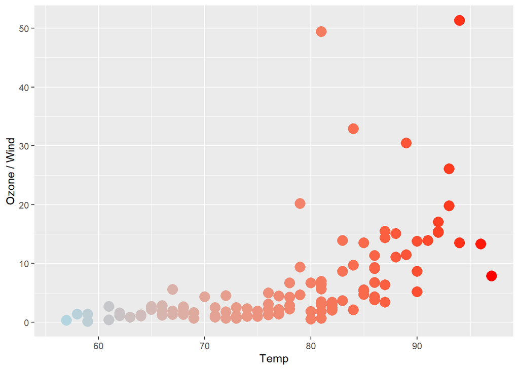

### max(ow)(Month)

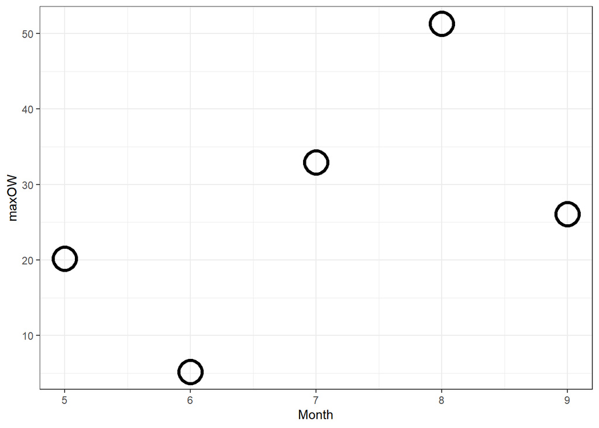

### Распределение ow по количеству

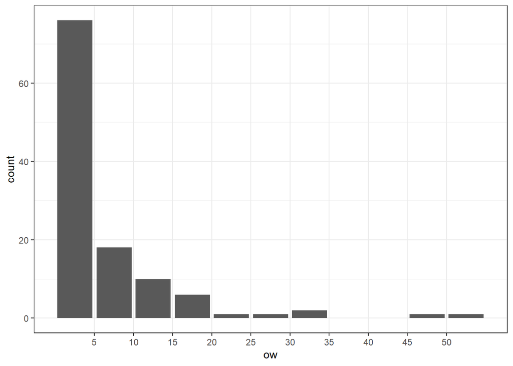

### Распределение ow в 5 месяце

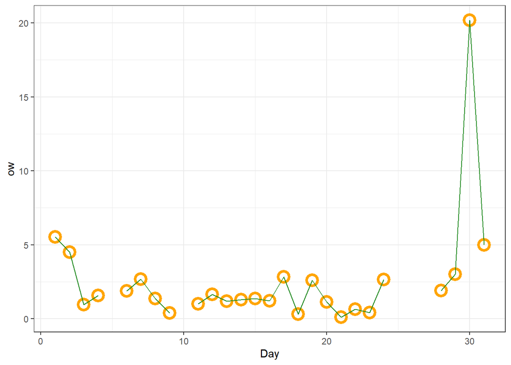

### Распределение ow в 6 месяце

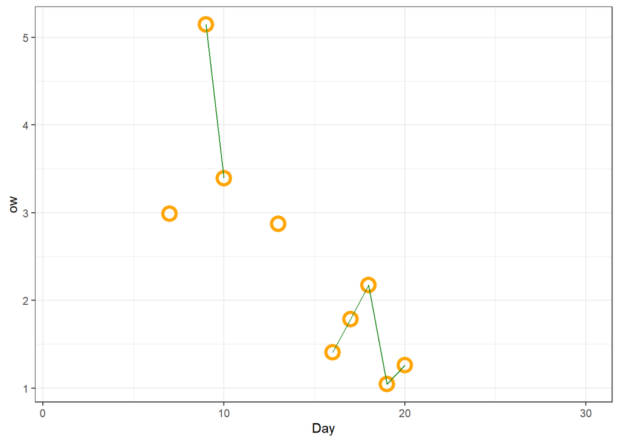

### Распределение ow в 7 месяце

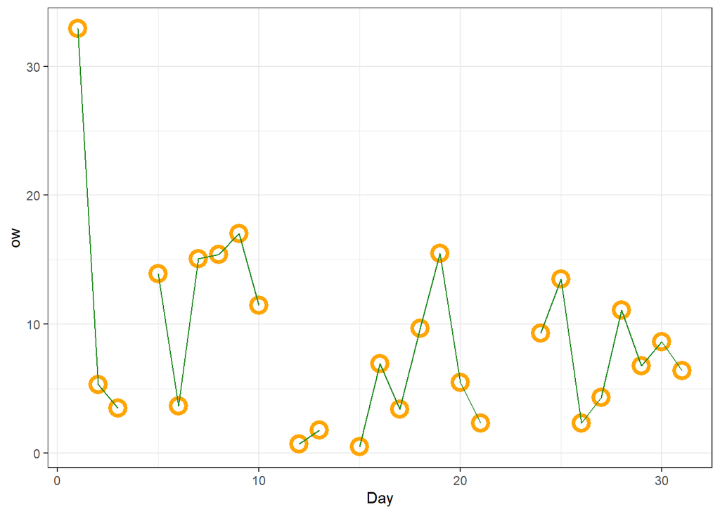

### Распределение ow в 8 месяце

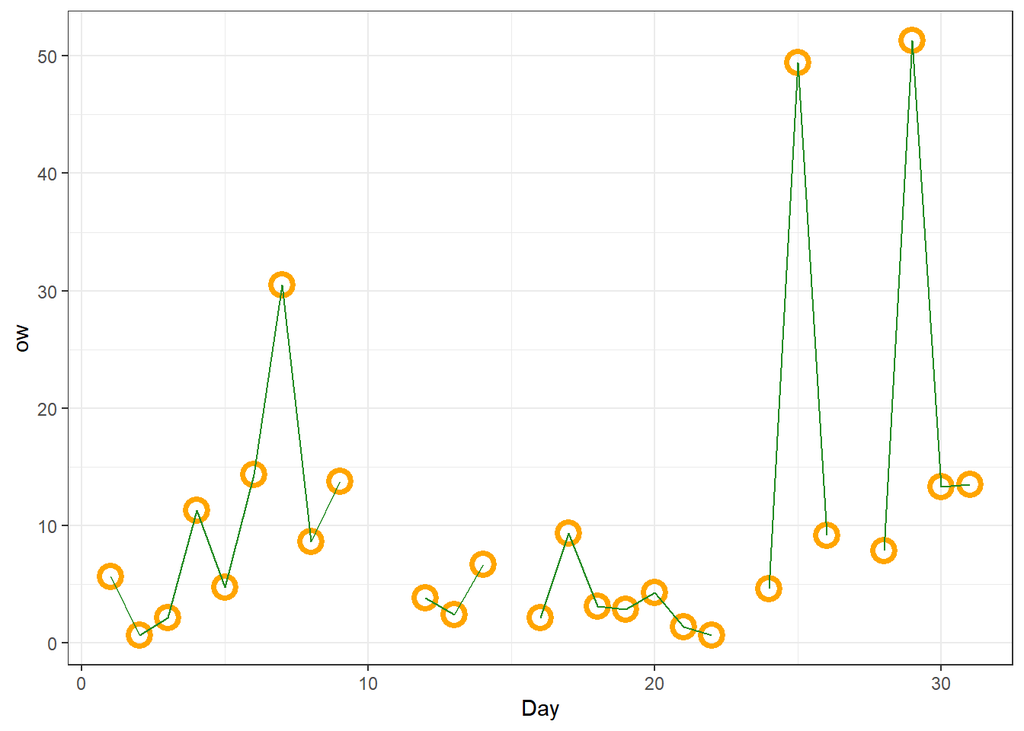

### Распределение ow в 9 месяце

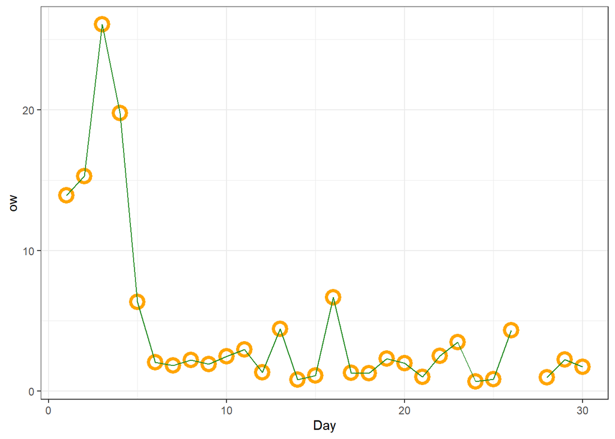

### Нормально ли распределение ow?

```
## [1] "ow = norm"
```